# Feature Engineering

2025-09-24

## What is Feature Engineering?

- The process of creating new, more predictive features from raw data.
- It uses domain knowledge to improve a simple predictive analysis.
- We’ll use a hypothetical e-commerce customer dataset as an example.

## Our Goal

- Understand the relationships between our variables and a customer’s `total_spend`.
- Use feature engineering techniques to transform existing variables and create new ones.
- Analyze the **correlation** of these features with `total_spend` to find stronger relationships.

## Our E-Commerce Dataset

This is our starting point: a raw dataset with customer information.

```
## # A tibble: 500 × 5
##    customer_id   age purchase_date product_category total_spend
##          <int> <dbl> <date>        <chr>                  <dbl>
##  1           1    33 2022-12-22    Electronics            377.
##  2           2    59 2022-12-18    Apparel                 20
##  3           3    39 2023-01-15    HomeGoods              105.
##  4           4    64 2023-04-01    Apparel                 20
##  5           5    67 2022-12-18    HomeGoods               20
##  6           6    20 2023-02-24    Electronics            912.
##  7           7    45 2022-10-17    Apparel                152.
##  8           8    64 2022-10-29    HomeGoods               56.6
##  9           9    47 2022-05-21    Electronics            380.
## 10          10    42 2022-12-27    Apparel                 88.4
## # ℹ 490 more rows
```

## Baseline Correlation

Before we do any feature engineering, let’s visualize the relationship between `total_spend` and `age` and then calculate the baseline **correlation** coefficient between the two variables.

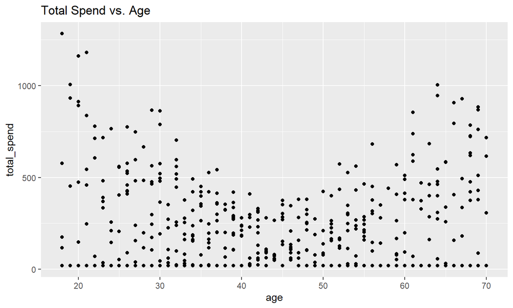

```
## Correlation of total_spend and age: -0.02692026
```

- The baseline linear correlation between `total_spend` and `age` is weak. This shows that the raw `age` variable, on its own, is not a strong predictor of customer spending in our dataset.

## Creating a New Feature: Days Since Purchase

We’ll start by creating a new feature: `days_since_purchase`. This is a more meaningful measure of a customer’s engagement than the raw `purchase_date`.

```r
# Feature Engineering: Calculate days since last purchase
customer_data <- customer_data %>%
  mutate(
    days_since_purchase = as.numeric(today - purchase_date)
  )

print(head(customer_data %>% select(customer_id, purchase_date, days_since_purchase)))
## # A tibble: 6 × 3
##   customer_id purchase_date days_since_purchase
##         <int> <date>                      <dbl>
## 1           1 2022-12-22                    130
## 2           2 2022-12-18                    134
## 3           3 2023-01-15                    106
## 4           4 2023-04-01                     30
## 5           5 2022-12-18                    134
## 6           6 2023-02-24                     66
```

- We’ve transformed a date variable into a numeric variable that is easier for models to interpret. A larger number of `days_since_purchase` suggests a less recent customer interaction.

## Correlation Analysis: New Feature

Let’s see if the correlation with `total_spend` is stronger for the new `days_since_purchase` feature than for the original `age` variable.

```
## Correlation of total_spend and age: -0.02692026
## Correlation of total_spend and days_since_purchase: -0.07640746
```

## Handling Categorical Data (One-Hot Encoding)

- Most correlation analyses require numerical data
- We want to know if the product categories are correlated with total spend
- We need to convert the string variable into variables for each category
- These are called binary indicator or dummy variables

```r
# Load the fastDummies package for one-hot encoding
library(fastDummies)
# Feature Engineering: One-hot encode the product_category
encoded_customer_data <- customer_data %>% dummy_cols(select_columns = "product_category")
# Print output
print(head(encoded_customer_data %>% select(product_category, starts_with("product_category_"))))
## # A tibble: 6 × 4
##   product_category product_category_Apparel product_category_Electronics
##   <chr>                               <int>                        <int>
## 1 Electronics                             0                            1
## 2 Apparel                                 1                            0
## 3 HomeGoods                               0                            0
## 4 Apparel                                 1                            0
## 5 HomeGoods                               0                            0
## 6 Electronics                             0                            1
## # ℹ 1 more variable: product_category_HomeGoods <int>
```

- Binary indicator variables convert a categorical feature into a numerical format

## Correlation Analysis: With One-Hot Encoded Variables

Let’s analyze the correlation between `total_spend` and each of the new one-hot encoded `product_category` variables.

```
## Correlation of total_spend and age: -0.02692026
## Correlation with Electronics purchases: 0.3099292
## Correlation with Apparel purchases: -0.1061958
## Correlation with Home Goods purchases: -0.1956324
```

- These correlations show that customers who purchase electronics have a much higher correlation with total spend than those who purchase apparel or home goods, confirming that product category is a key factor.
- This is a much stronger relationship than what we see with the original age variable.

## Creating a New Feature: Interaction Term

We can create a new feature by multiplying two existing features, such as `age` and `days_since_purchase`. This can capture a more complex relationship where the effect of one variable depends on the other.

```r
# Feature Engineering: Create an interaction term
customer_data <- customer_data %>%
  mutate(age_x_days_since_purchase = age * days_since_purchase)

print(head(customer_data %>% select(customer_id, age, days_since_purchase, age_x_days_since_purchase)))
## # A tibble: 6 × 4
##   customer_id   age days_since_purchase age_x_days_since_purchase
##         <int> <dbl>               <dbl>                     <dbl>
## 1           1    33                 130                      4290
## 2           2    59                 134                      7906
## 3           3    39                 106                      4134
## 4           4    64                  30                      1920
## 5           5    67                 134                      8978
## 6           6    20                  66                      1320
```

- This new interaction term can help a model understand if the effect of `age` on spending changes depending on how long it’s been since a purchase, or vice versa.

## Correlation Analysis: With Interaction Term

Now let’s see how the new interaction term correlates with `total_spend`.

```
## Correlation of total_spend and age: -0.02692026
## Correlation of total_spend and days_since_purchase: -0.07640746
## Correlation of total_spend and age_x_days_since_purchase: 0.1562378
```

## Visualizing the Interaction Effect

Let’s create a visualization to better understand how the interaction works:

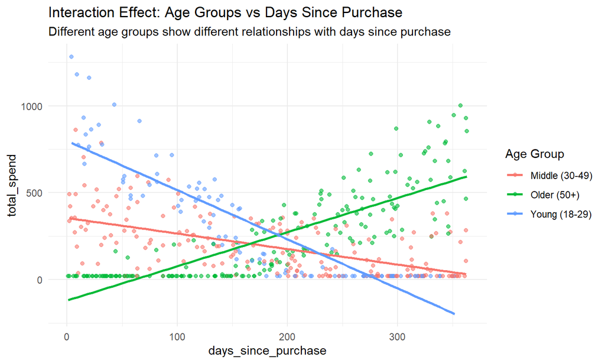

- This plot reveals how the relationship between days since purchase and total spend varies by age group, illustrating the interaction effect.

## Polynomial Transformation

Sometimes a linear relationship isn’t enough. We can capture a curved relationship by creating a new polynomial feature, for example, squaring the `days_since_purchase` variable.

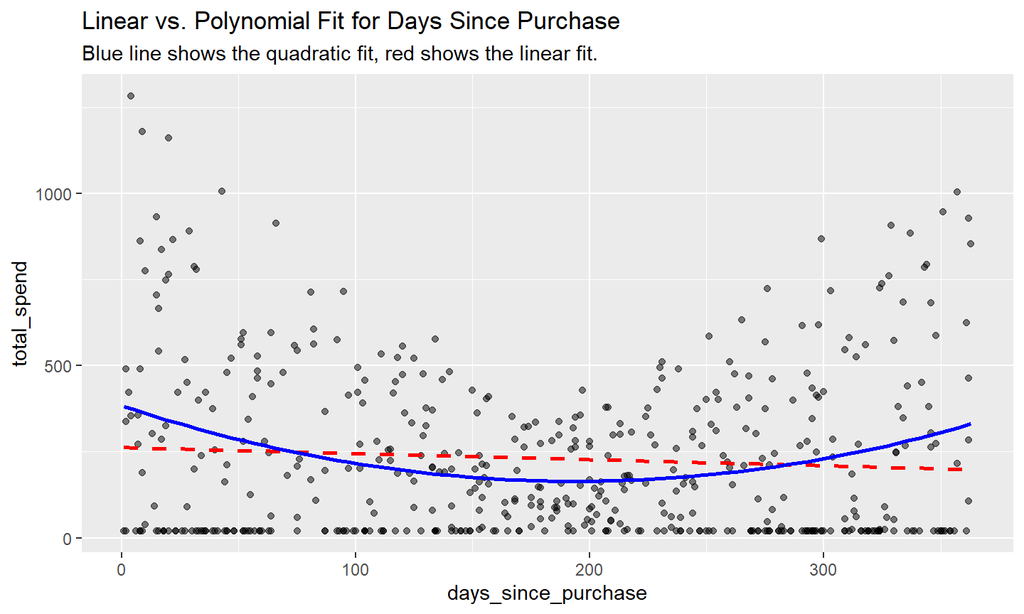

- The plot shows the comparison between linear and polynomial relationships with days since purchase.

## Correlation Analysis: With Polynomial Feature

Let’s see if the squared version of `days_since_purchase` has a stronger correlation with `total_spend` than the original.

```
## Correlation of total_spend and days_since_purchase: -0.07640746
## Correlation of total_spend and days_since_purchase_squared: -0.01306788
## Correlation of total_spend and age_x_days_since_purchase: 0.1562378
```

## Connecting the Pieces: From Part I to Part II

The skills we learned in Part I are the essential building blocks for Part II.

- **Data Wrangling (Part I):** We first learned to use `dplyr` and `tidyr` to clean and structure our data. This step is a prerequisite for feature engineering—we can’t create new features if our data isn’t in a usable format.
- **Exploratory Data Analysis (Part I):** We used `ggplot2` to visualize our data. This process helped us discover patterns and relationships that give us the ideas for *what new features to create* in this session.
- **Supervised Learning (Part II):** In the next part of the course we’ll discuss the models that will use the wrangled data sets that we created in part I.